# Part A

#### Answer 3D

```python
print(f'Number of outliers = {len(data[data.Funds_in_million > up_limit])}')

data[data.Funds_in_million > up_limit]
```

[output not shown]

[output not shown]

#### Answer 3E

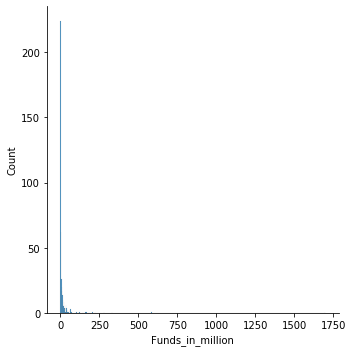

```python
sns.displot(data.Funds_in_million)
```

```python
data.Funds_in_million.describe()
```

[output not shown]

```python
data
```

|  | Startup | Product | Funding | Event | Result | OperatingState | Funds_in_million |
| --- | --- | --- | --- | --- | --- | --- | --- |
| 1 | 3DLT | 3dlt.com | $630K | Disrupt NYC 2013 | Contestant | Closed | 0.63 |
| 3 | 3Dprintler | 3dprintler.com | $1M | Disrupt NY 2016 | Audience choice | Operating | 1.00 |
| 5 | 5to1 | 5to1.com | $19.3M | TC50 2009 | Contestant | Acquired | 19.30 |
| 6 | 8 Securities | 8securities.com | $29M | Disrupt Beijing 2011 | Finalist | Operating | 29.00 |
| 10 | AdhereTech | adheretech.com | $1.8M | Hardware Battlefield 2014 | Contestant | Operating | 1.80 |
| ... | ... | ... | ... | ... | ... | ... | ... |
| 657 | Zivity | zivity.com | $8M | TC40 2007 | Contestant | Operating | 8.00 |
| 658 | Zmorph | zmorph3d.com | $1M | - | Audience choice | Operating | 1.00 |
| 659 | Zocdoc | zocdoc.com | $223M | TC40 2007 | Contestant | Operating | 223.00 |
| 660 | Zula | zulaapp.com | $3.4M | Disrupt SF 2013 | Audience choice | Operating | 3.40 |
| 661 | Zumper | zumper.com | $31.5M | Disrupt SF 2012 | Finalist | Operating | 31.50 |

446 rows × 7 columns

#### Answer 3E

```python
data['OperatingState'].value_counts()
```

```
Operating    319
Acquired      66
Closed        57
Ipo            4
Name: OperatingState, dtype: int64
```

[output not shown]

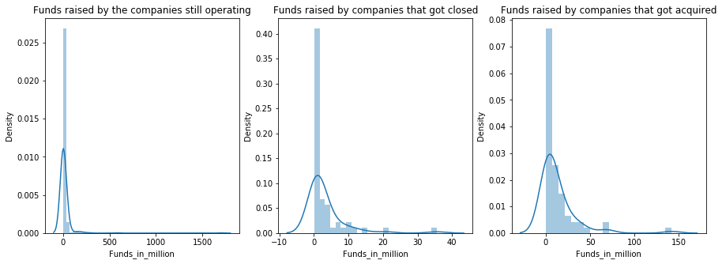

```python
fig, ax = plt.subplots(1,3)

fig.set_figheight(5)
fig.set_figwidth(15)

sns.distplot(data.loc[data.OperatingState == 'Operating', 'Funds_in_million'], ax = ax[0])
sns.distplot(data.loc[data.OperatingState =='Closed', 'Funds_in_million'], ax = ax[1])
sns.distplot(data.loc[data.OperatingState =='Acquired', 'Funds_in_million'], ax = ax[2])

ax[0].set_title('Funds raised by the companies still operating')
ax[1].set_title('Funds raised by companies that got closed')
ax[2].set_title('Funds raised by companies that got acquired')
plt.show()
```

### Answer 4

#### Answer 4A

From above figures for Operating and Closed companies, it's evident that there's not much difference between data for Operating and Closed companies. However, in order to find the differences we will run Hypothesis test. Also, distribution is not exactly normal but since sample sizes > 30, we will assume Central Limit Theorem to hold good here and we will proceed ahead with z-test and t-test.

#### Answer 4B

For the test..-

**Null Hypothesis**: There is no difference between two means

**Alternate Hypothesis**: There is significant difference between two means

#### Answer 4C

```python
from statsmodels.stats.weightstats import ztest

sample_1=data.loc[data['OperatingState']=='Operating','Funds_in_million']
sample_2=data.loc[data.OperatingState=='Closed','Funds_in_million']

test_statistic, p_value=ztest(sample_1,sample_2)

alpha_significance=.05 # Taking Confidence interval 95%

if p_value <= alpha_significance:
    print(f'Since p_value < alpha_significance, hence we Reject Null hypothesis')

else:
    print(f'Since p_value {round(p_value,4)} > {alpha_significance} (alpha), hence we Fail to reject Null Hypothesis and this means there is NO significant difference')

#test_statistic,p-value
```

```
Since p_value 0.255 > 0.05 (alpha), hence we Fail to reject Null Hypothesis and this means there is NO significant difference
```

```python
p_value
```

```
0.25499838490589677
```

```python
from scipy.stats import ttest_ind

test_statistic, p_value= ttest_ind(sample_1,sample_2)

aplha_significance=.05 # Taking confidence interval .05

if p_value<alpha_significance:
    print(f'Since p_value {p_value} < {alpha_significance} (alpha), hence we reject Null hypothesis and this means there is difference')

else:
    print(f'Since p_value {p_value} > {alpha_significance} (alpha), hence we fail to reject Null Hypothesis and this means there is NO difference')
```

```
Since p_value 0.25572701885629406 > 0.05 (alpha), hence we fail to reject Null Hypothesis and this means there is NO difference
```

- From above Hypothesis tests, we can conclude that more Funding does not lead to more success or vice versa

#### Answer 4D

```python
df2 = df1.copy()
df2.head()
```

|  | Startup | Product | Funding | Event | Result | OperatingState |
| --- | --- | --- | --- | --- | --- | --- |
| 0 | 2600Hz | 2600hz.com | NaN | Disrupt SF 2013 | Contestant | Operating |
| 1 | 3DLT | 3dlt.com | $630K | Disrupt NYC 2013 | Contestant | Closed |
| 2 | 3DPrinterOS | 3dprinteros.com | NaN | Disrupt SF 2016 | Contestant | Operating |
| 3 | 3Dprintler | 3dprintler.com | $1M | Disrupt NY 2016 | Audience choice | Operating |
| 4 | 42 Technologies | 42technologies.com | NaN | Disrupt NYC 2013 | Contestant | Operating |

```python
df2.shape
```

```
(662, 6)
```

#### Answer 4E

```python
df2.Result.value_counts()
```

```
Contestant         488
Finalist            84
Audience choice     41
Winner              26
Runner up           23
Name: Result, dtype: int64
```

```python
## There are 488 contestants and rest came out as something more. For now, we will call 'rest' as winners
```

**Answer 4F**

```python
contestants=len(df2[df2['Result']=='Contestant'])
contestants
```

```
488
```

```python
winners = len(df2[df2['Result']=='Finalist'])+len(df2[df2['Result']=='Audience choice'])+len(df2[df2['Result']=='Winner'])+len(df2[df2['Result']=='Runner up'])
winners
```

```
174
```

```python
contestants_operating = df2.OperatingState[df2.Result == 'Contestant'].value_counts().loc['Operating']
winners_operating = df2.OperatingState[df2.Result != 'Contestant'].value_counts().loc['Operating']
```

```python
contestants_operating
```

```
332
```

```python
winners_operating
```

```
133
```

```python
print(f'Percentage of winners that are still operating is winners_operating / winners: {winners_operating/winners}')
```

```
Percentage of winners that are still operating is winners_operating / winners: 0.764367816091954
```

```python
print(f'Percentage of contestants that are still operating is contestants_operating / contestants: {contestants_operating/contestants}')
```

```
Percentage of contestants that are still operating is contestants_operating / contestants: 0.680327868852459
```

**Answer 4G**

**Null hypothesis**: There is no difference between proportions of winners and contestants

**Alternate Hypothesis**: There is significant difference between proportions of winners and contestants

**Answer 4H**

```python
from statsmodels.stats.proportion import proportions_ztest

test_statistic, p_value = proportions_ztest([contestants_operating, winners_operating], [contestants, winners])

alpha = .05

if p_value <= alpha:
    print(f'Since the p-value, {round(p_value, 4)} < {alpha} (alpha) the difference is significant and we reject the Null hypothesis')
else:
    print(f'Since the p-value, {round(p_value,4)} > {alpha} (alpha) the difference is not significant and, we fail to reject the Null hypothesis')
```

```
Since the p-value, 0.0374 < 0.05 (alpha) the difference is significant and we reject the Null hypothesis
```

**Answer 4I**

```python
events = df1[df1.Event.apply(lambda x: 'Disrupt' in x and int(x[-4:]) > 2012)].Event  # all the events happening in or after 2013
events
```

```
0          Disrupt SF 2013
1         Disrupt NYC 2013
2          Disrupt SF 2016
3          Disrupt NY 2016
4         Disrupt NYC 2013
              ...
646    Disrupt London 2015
648    Disrupt London 2015
653        Disrupt EU 2014
656       Disrupt NYC 2013
660        Disrupt SF 2013
Name: Event, Length: 276, dtype: object
```